# pa1_template

Chris Job

April 19, 2016

**Load libraries**

```r
library(data.table)
library("lubridate")
```

```r
library(grid)
library(ggplot2)
library(grid)
library(dplyr)
library(lattice)
library(knitr)
#setwd("/Volumes/KINGSTON/moocs/coursera/datascience/represearch/week1")
setwd('f:/moocs/coursera/datascience/represearch/week1')
```

**Read in activity file**

```r
f1 <- file.path(getwd(), "activity.csv")
activeData <- read.table(f1,sep=',',stringsAsFactors=FALSE,header=TRUE)
#head(activeData)
```

*1. Transform data so that we have total steps taken each day*

```r
totalStepsPerDay <- tapply(activeData$steps, activeData$date, sum, na.rm=TRUE)
#head(totalStepsPerDay)
```

*2. Histogram of total steps taken per day*

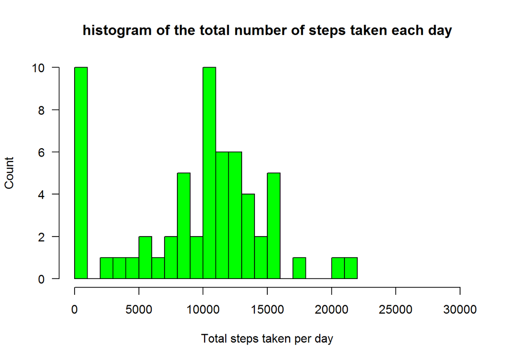

```r
hist(totalStepsPerDay, main= "histogram of the total number of steps taken each day", xlab="Total steps taken per day", ylab="Count", las=1,breaks=30, col="green", xlim=c(0,30000), ylim=c(0,10))
```

*3. mean and median of the total number of steps taken per day*

```r
mean(totalStepsPerDay)
```

```
## [1] 9354.23
```

```r
median(totalStepsPerDay)
```

```
## [1] 10395
```

**Mean of totalSteps Per Day: 9354.23**

**Median of total Steps Per Day: 10395**

### What is the average daily activity pattern?

*1. Make a time series plot of the 5-minute interval (x-axis) and the average number of steps taken, averaged across all days (y-axis)*

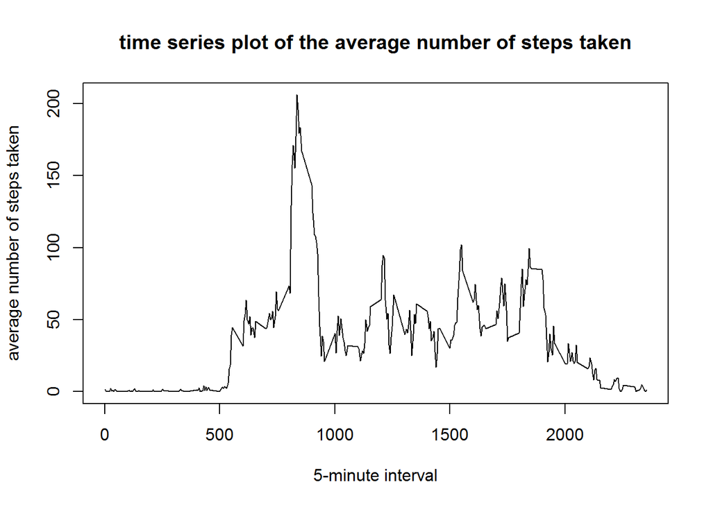

```r
aveSteps <- aggregate(x=list(steps=activeData$steps), by=list(interval=activeData$interval),FUN=mean, na.rm=TRUE)
#head(aveSteps)

plot(aveSteps,type='l', xlab("5-minute interval"), ylab("average number of steps taken"),main="time series plot of the average number of steps taken")
```

*2. Which 5-minute interval, on average across all the days in the dataset, contains the maximum number of steps?*

```r
aveSteps[which.max(aveSteps$steps),]
```

```
##     interval    steps
## 104      835 206.1698
```

```
        interval    steps

104      835      206.1698
```

### Imputing missing values

```r
missStepsData <- is.na(activeData)
sum(missStepsData)
```

```
## [1] 2304
```

**Total number of missing values: 2304**

*2. Devise a strategy for filling in all of the missing values in the dataset.*

*3. Create a new dataset that is equal to the original dataset but with the missing data filled in*

```r
activeData2<-activeData #Create a new data set
avgStepsPerInterval <- tapply(activeData2$steps, activeData2$interval, mean, na.rm=TRUE, simplify=TRUE)
#head(avgStepsPerInterval)

#is.na(activeData2$steps) #creates a vector of the logical value of NA's as TRUE
#which(is.na(activeData2$steps)) #creates a vector of the indices of the TRUE values

#use the indices to change the NA values to mean of steps per day
activeData2$steps[which(is.na(activeData2$steps))] <- avgStepsPerInterval
#head(activeData2)
```

*4. Histogram, Mean and Median*

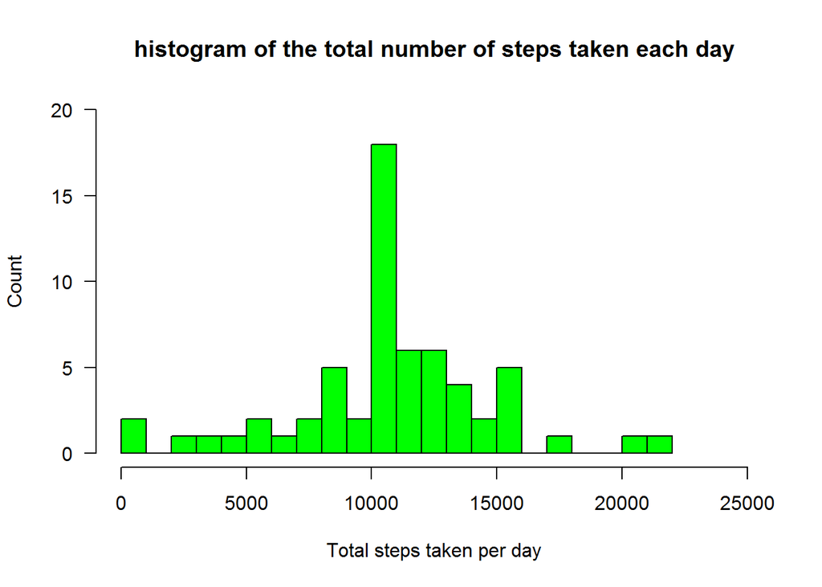

```r
totalStepsPerDay2 <- tapply(activeData2$steps, activeData2$date, sum, na.rm=TRUE)
#head(totalStepsPerDay2)
hist(totalStepsPerDay2 , main= "histogram of the total number of steps taken each day", xlab="Total steps taken per day", ylab="Count", las=1,breaks=30, col="green", xlim=c(0,25000), ylim=c(0,20))
```

```r
mean(totalStepsPerDay2)
```

```
## [1] 10766.19
```

```r
median(totalStepsPerDay2)
```

```
## [1] 10766.19
```

**Mean of totalSteps Per Day: 10766.19**

**Median of total Steps Per Day: 10766.19**

### Are there differences in activity patterns between weekdays and weekends?

```r
activeData3<-activeData2

weekend <- weekdays(as.Date(activeData3$date)) %in% c("Saturday", "Sunday") #logical vector of weekend (TRUE) and weekdays(FALSE)

activeData3['daytype'] <- "weekday" # Create a new column for type of day and fill with default value
#head(activeData3)

activeData3$daytype[weekend =='TRUE'] <- "weekend" #Change default value for weekend days

activeData3$daytype <- as.factor(activeData3$daytype) #convert to factor

#str(activeData3)

aveSteps3 <- aggregate(steps ~ interval + daytype,  activeData3, mean)
#head(aveSteps3)
```

### plot time series

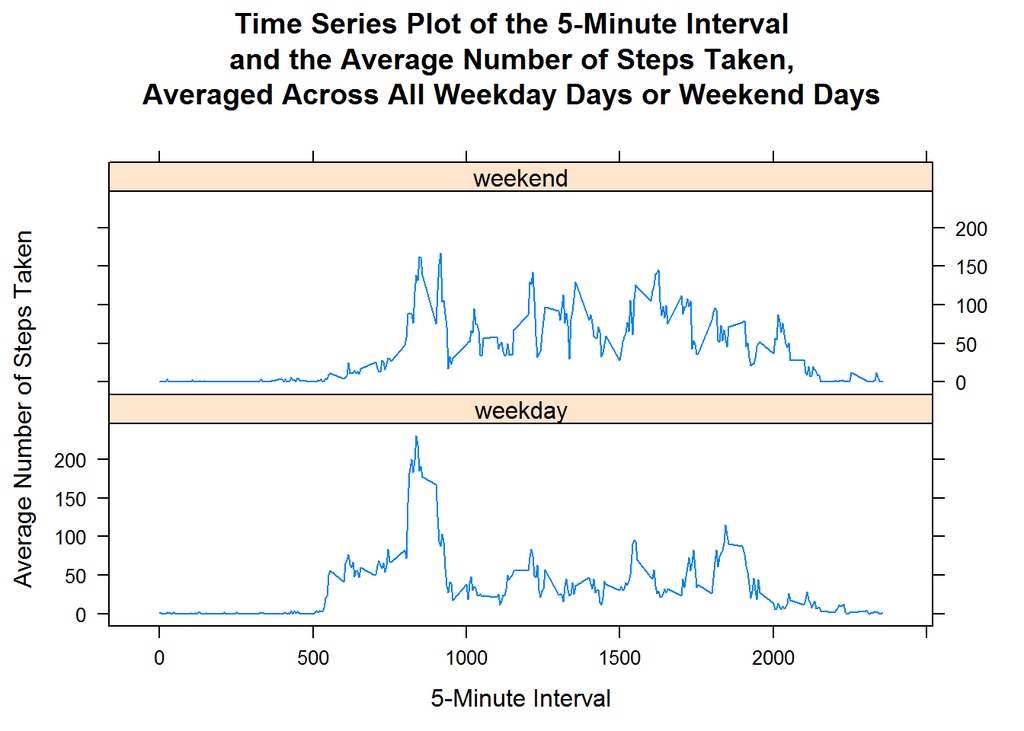

```r
xyplot(steps ~ interval | daytype, aveSteps3, type = "l", layout = c(1,2), main = "Time Series Plot of the 5-Minute Interval\nand the Average Number of Steps Taken,\nAveraged Across All Weekday Days or Weekend Days", xlab = "5-Minute Interval", ylab = "Average Number of Steps Taken")
```